# ACP parcimonieuse

2018-03-28

## Contenu

- Introduction du concept
- Exemple de motivation
- Description de la méthodologie
- Justification de la méthodologie
- Exemple d'application
- Autres implications

## Réduction de la dimensionnalité

Les techniques de réduction de la dimensionnalité ont comme objectifs de réduire le nombre de variables observées dans le but de:

- Simplifier l'interprétation des données.
- Visualiser les données.
- Améliorer la performance certaines autres méthodes.

## L'ACP

L'analyse en composantes principales est méthode classique de réduction de la dimensionnalité.

**Objectif**

Obtenir une représentation des données dans un espace plus restreint en conservant la plus grande quantité d'information possible.

- On crée des combinaisons linéaires des \(p\) variables.
- On maximise la variance à chacune des composantes.

## Notation

Soit le jeu de données représenté par:

\(\mathbf{X} = (X_1, ..., X_p)^\top\)

avec une matrice de covariance \(\Sigma = \text{var}(\mathbf{X})\).

La première composante principale est donnée par:

\(Y_1 = \alpha^{\top}_{1}\mathbf{X}\)

qui maximise \(\text{var}(Y_1) = \lambda_1\).

## Décomposition en valeurs singulières

Ce problème d'optimisation peut être résoud plus aisément avec une décomposition en valeurs singulières (SVD) de la matrice \(\Sigma\).

- Les vecteurs \(\alpha_1, ..., \alpha_p\) sont donnés par les vecteurs propres normés.
- Les variances \(\lambda_1, ..., \lambda_p\) pour chacune des composantes principales sont données par les valeurs propres.

## Le résultat de l'ACP

On peut utiliser le résultat de la décomposition en valeurs singulières pour analyser deux choses:

1. L'importance relative de chacune des variables dans chacune des composantes principales via les vecteurs de coefficients de saturation (\(\alpha_1, ..., \alpha_p\)).
2. La quantité d'information contenue dans chacune des composantes principales via les valeurs propres (\(\lambda_1, ..., \lambda_p\)).

## Les inconvéniants de l'ACP

Voici les vecteurs de coefficients de saturation pour les \(4\) premières composantes principales du jeu de données \(\texttt{pitprops}\) de la librarie **elasticnet**.

```
##                 PC1         PC2         PC3         PC4
## topdiam -0.40379375 -0.21785161  0.20729009 -0.09121408
## length  -0.40554469 -0.18612694  0.23503529 -0.10271814
## moist   -0.12440384 -0.54064233 -0.14148843  0.07844352
## testsg  -0.17322061 -0.45563728 -0.35242301  0.05477390
## ovensg  -0.05717394  0.17007092 -0.48121257  0.04911295
## ringtop -0.28442510  0.01419526 -0.47525703 -0.06343453
## ringbut -0.39984124  0.18963655 -0.25310152 -0.06498405
## bowmax  -0.29355595  0.18915250  0.24305282  0.28554422
## bowdist -0.35662900 -0.01712421  0.20764231  0.09672331
## whorls  -0.37891541  0.24845341  0.11876670 -0.20504369
## clear    0.01109383 -0.20530293  0.07045228  0.80365507
## knots    0.11508371 -0.34317293 -0.09199914 -0.30080388
## diaknot  0.11251370 -0.30853263  0.32611380 -0.30337798
```

## Les méthodes d'interprétation

Plusieurs méthodes existent pour palier au problème d'interprétation:

- Les rotations (varimax, promax, etc)
- Écarter les coefficients inférieurs à une certaine valeur
- Limiter les valeurs possibles que les coefficients peuvent prendre (ex: \(\{-1,0,1\}\))

## Rotation varimax

La rotation varimax est une rotation orthogonale classique est bien souvent implémentée par défaut dans les logiciels.

```
##                 RC1         RC2          RC3          RC6
## topdiam  0.91158833  0.25525200  0.003248157 -0.106347025
## length   0.93507670  0.18317241  0.012882669 -0.127165342
## moist    0.13423685  0.96065807 -0.134226396 -0.040882526
## testsg   0.12499995  0.94359170  0.246142189  0.019936208
## ovensg  -0.14943647  0.02436959  0.896696850  0.015024738
## ringtop  0.35345951  0.17711297  0.637609226  0.472223116
## ringbut  0.62462240 -0.02540720  0.495767182  0.517454238
## bowmax   0.55829922 -0.08636790 -0.089869218  0.206089302
## bowdist  0.77348209  0.02754277 -0.017436051  0.093585151
## whorls   0.68731321 -0.09027095  0.035006876  0.312010462
## clear    0.05138797  0.07628607 -0.045092225  0.005857861
## knots   -0.06634932  0.12108227 -0.133540921 -0.068608640
## diaknot  0.07523732  0.03390112 -0.081548122 -0.930061440
```

## Variance dans les premières composantes principales

Voici la quantité d'information (variance) pour les 6 premières composantes principales:

```
##                     mesure   PC1   PC2   PC3   PC4   PC5   PC6
## 1:            Variance (%) 32.45 18.29 14.45  8.53  7.00  6.27
## 2: Variance cumulative (%) 32.45 50.74 65.19 73.73 80.73 87.00
```

```
##                     mesure PC1 PC2 PC3 PC6 PC5 PC4
## 1:            Variance (%)  28  15  12  12  11   9
## 2: Variance cumulative (%)  28  43  56  67  78  87
```

## Les inconvéniants

Plusieurs désavantages peuvent survenir avec ce type de méthode:

- Instabilité dans les interprétations.
- Perte d'information dans les premières composantes principales.

## L'ACP parcimonieuse

Les méthodes introduites dans cette présentation permettront de combiner en **une seule étape** l'ACP avec les autres méthodes d'interprétation.

- Améliorer l'interprétation en obtenant des coefficients de saturation excatement égales à 0.
- Maximiser la quantitié d'information contenue dans chacune des composantes principales en tenant compte de certaines contraintes d'interprétabilité.

## Description de la méthodologie

On verra deux méthodes d'analyse en composantes principales parcimonieuses:

1. SCoTLASS: Simplifed Component Technique LASSO
2. SPCA: Sparse Principal Component Analysis

## Rappel: les méthodes de régularisation

Il existe plusieurs méthodes de régularisation, on en citera trois:

1. La méthode de Ridge
2. La méthode du Lasso
3. La méthode d'Elastic Net

## Rappel: les méthodes de régularisation

Dans le cadre d'une régression multiple: \[Y= X\beta +\epsilon\]

tel que \[\beta=(\beta_0, \beta_1,\beta_2, ..., \beta_p)^T\]

et \[X=(1,X_1,...,X_p)\]

## La méthode de Ridge

- Elle se base base sur la norme \(L_2\).
- La pénalité est donnée par \(p(\beta)= ||\beta||^2_2\) avec \(||\beta||^2_2 = \sum_{i=1}^{p} \beta^2_i\).
- Le problème d'optimisation: \[\hat \beta^{Ridge}= argmin_\beta \{\sum_{i=1}^n(y_i-\beta_0 -\sum_{j=1}^p x_{ij}\beta_j)^2\}\]

sous la contrainte de \[\sum_{j=1}^p \beta^2_j \leq t\].

## La méthode du Lasso

- Elle se base base sur la norme \(L_1\).
- La pénalité est donnée par \(p(\beta)=||\beta||_1\) avec \(||\beta||_1 = \sum_{i=1}^{p} |\beta_i|\).
- Le problème d'optimisation: \[\hat\beta^{Lasso}= argmin_\beta \{\sum_{i=1}^n(y_i-\beta_0 -\sum_{j=1}^p x_{ij}\beta_j)^2\}\]

sous la contrainte de \[\sum_{j=1}^p |\beta|_j \leq t\].

## La méthode Elastic Net

- Elle combine les deux normes (\(L_1\) et \(L_2\)).
- Sa pénalité est donnée par \(p(\beta)=\lambda_1 ||\beta||_1 +\lambda_2 ||\beta||^2_2\).
- Le problème d'optimisation: \[\hat\beta^{EN}= argmin_\beta\{||y-X\beta||^2\ + \lambda_1 ||\beta||_1 +\lambda_2 ||\beta||^2_2 \}\]

## Comparaison des méthodes de régularisation

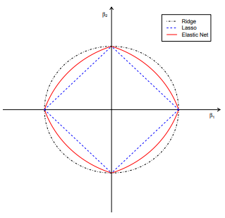

## SCoTLASS: Optimisation

Le problème d'opitimisation et les contraintes sont les mêmes que dans le contexte de l'ACP, mais on ajoute une contrainte sur les coefficients de saturation.

On ajoute la contrainte suivante:

\[\sum_{j=1}^{p} |\alpha_{kj}| \leq t\]

## SCoTLASS: Choix de \(t\)

Le choix de l'hyperparamètre \(t\) affectera la solution de la méthode de différentes façons.

1. Pour \(t \geq \sqrt{p}\), on retrouve l'ACP classique.
2. Pour \(t \leq 1\), il n'existe pas de solution.
3. Pour \(t=1\), on a exactement une valeur non nulle de \(\alpha_{kj}\) pour chaque k.

En bref, en sélectionnant une valeur de \(t\) entre 1 et \(\sqrt{p}\), on fait une sélection sur les coefficients \(\alpha_1, ..., \alpha_p\).

## SCoTLASS: Choix de \(t\)

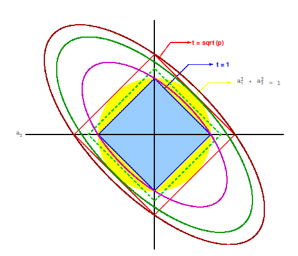

## SCoTLASS: Inconvénients

La méthode comporte certains inconvénients.

- Choix de \(t\) peut être difficile
- Problème non convexe
- Calculs difficiles

## SPCA: Intuition

Soit \(Y_k =\alpha'_k X\) la kième composante principale obtenue à partir d'une ACP.

Ces coefficients de saturation \(\alpha_k\) peuvent aussi être obtenus en faisant une regression multiple de la composante principale sur la matrice \(X\) (\(Y_k = X\beta + \epsilon\)).

- On utilise l'erreur de reconstruction et non la décomposition en valeurs singulières pour trouver les valeurs de \(\alpha_k\).

## SPCA: La méthode simple

La méthode est basée sur deux concepts centraux.

- **La reconstruction:** Pour éviter tout problème de contruction des axes, on ajoute la pénalité de Ridge \(L_2\), le problème d'optimisation devient: \[\hat\beta = argmin_\beta ||Y_k -X\beta||+\lambda||\beta||_2^2 \quad(1)\]
- **La parcimonie:** On rajoute la pénalité du Lasso \(L_1\) pour avoir des axes parcimonieux. Le problème d'optimisation devient: \[\hat\beta = argmin_\beta ||Y_k -X\beta||+\lambda||\beta||_2^2+\lambda_1||\beta||_1 \quad(2)\]

La kième composante principale approximée est \(X \hat V_k= X \frac{\hat\beta}{||\hat \beta||}\).

## SPCA: La méthode simple

Un inconvénient rattaché à cette méthode est que le résultat est dépendant des résultats otbtenus en faisant l'ACP. En effet, l'objectif est de faire la régression sur les composantes principales produites par l'ACP.

**Solution:** On peut généraliser la méthode et itérativement reproduire de nouvelles composantes principales qui amélioront les résultats de la régression.

- L'ACP deviendra seulement le point de départ.

## SPCA: La généralisation

Considérons la notation suivante:

- \(\mathbf{X}\): la matrice d'observations
- \(x_i\): la ième ligne de cette matrice
- \(A_{p\times k}=[\alpha_1,\alpha_2,...,\alpha_k]\): les k premières composantes principales
- \(B_{p\times k}=[\beta_1,\beta_2,....,\beta_k]\): les k premières composantes principales estimées de tel sorte que les composantes principales soient parcimonieuses

## SPCA: La généralisation

- Le problème d'optimisation devient: \[(\hat A, \hat B)= argmin_{A,B} \sum_{i=1}^n||x_i -AB^Tx_i||^2 \\+\lambda \sum_{j=1}^{k}||\beta_j||^2+ \sum_{j=1}^{k}\lambda_{1,j}||\beta_j||_1\] Sous la contrainte: \[A^TA=I_{k*k}\]

## SPCA: Algorithme alterné sur A et B

On suppose que A est connu et on cherche B

\[\hat\beta_j= argmin_{\beta_j} ||Y_j -X\beta_j||^2 +\lambda||\beta_j||^2+ \lambda_{1,j}||\beta_j||_1\]

\[\hat\beta_j =arg min_{\beta_j}( \alpha_j-\beta_j)^TX^TX(\alpha_j-\beta_j)+\lambda||\beta_j||^2 +\lambda_1,j||\beta_j||_1\]

## SPCA: Algorithme alterné sur A et B

On suppose que B est connu et on cherche A (on ignore la pénalité qui est liée aux termes de \(B\))

\[min_\beta \sum_{i=1}^k ||x_i-AB^Tx_i||^2 =||X-XBA^T||\]

Sous la contrainte: \[A^TA=I_{k*k}\]

## SPCA: Algorithme

1. On commence par \(A = [\alpha_1, ..., \alpha_k]\) les coefficients de saturation des k premières composantes principales.
2. Sachant \(A= [\alpha_{1}, ...,\alpha_{k}]\), on résout le problème d'optimisation et on trouve l'estimation de \(B\).
3. Pour une matrice \(B=[\beta_1, ..., \beta_k]\) fixée, on recalcule \(A\) et on met sa valeur à jour.
4. On répète les étapes 2-3 jusqu'à la convergence.
5. On normalise V, \(\hat V_j = \frac{\beta_j}{||\beta_j||}\)

Les \(V_j\) sont les nouvelles composantes principales parcimonieuses.

## Justification de la méthodologie

**Objectif de l'étude de simulation:**

Comparer la performance de l'ACP parcimonieuse par rapport à la méthode de rotation en termes de mieux représenter la réalité.

Pour y arriver, nous allons définir \(3\) structures différentes de coefficients de saturation que nous voulons reproduire à partir des différentes méthodes d'analyse en composantes principales.

## Définir le point d'arrivée

On commence par définir les vecteurs et valeurs propres que nous voulons essayer de recréer à partir des différentes méthodes d'analyse en composantes principales.

1. **Structure en blocks:** Construite de manière à ce qu’il y aille 3 variables plus importantes et 3 variables moins importantes dans chacune des composantes principales.
2. **Strucuture uniforme:** Construite de manière à avoir des coefficients de saturation proches les uns des autres pour chacune des composantes principales.
3. **Structure intermédiaire:** Construite de manière à avoir une structure intermédiaire aux deux premières.

## Structure en blocks

```r
print(data_structure_blocks)
```

```
##    variable   PC1    PC2    PC3    PC4    PC5    PC6
## 1:       x1 0.096 -0.537  0.759 -0.120  0.335 -0.021
## 2:       x2 0.082 -0.565 -0.599  0.231  0.511 -0.013
## 3:       x3 0.080 -0.608 -0.119 -0.119 -0.771  0.016
## 4:       x4 0.594  0.085 -0.074 -0.308  0.069  0.731
## 5:       x5 0.584  0.096 -0.114 -0.418  0.052 -0.678
## 6:       x6 0.533  0.074  0.180  0.805 -0.157 -0.069
```

## Structure uniforme

```r
print(data_structure_plattes)
```

```
##    variable    PC1   PC2    PC3    PC4    PC5    PC6
## 1:       x1 -0.455 0.336 -0.087  0.741 -0.328  0.125
## 2:       x2 -0.439 0.370 -0.212 -0.630 -0.445 -0.175
## 3:       x3 -0.415 0.422  0.378 -0.110  0.697  0.099
## 4:       x4  0.434 0.458  0.040 -0.136 -0.167  0.744
## 5:       x5  0.301 0.435 -0.697  0.114  0.356 -0.306
## 6:       x6  0.385 0.416  0.563  0.104 -0.234 -0.545
```

## Structure intermédiaire

```r
print(data_structure_intermediaire)
```

```
##    variable   PC1    PC2    PC3    PC4    PC5    PC6
## 1:       x1 0.224 -0.509  0.604  0.297 -0.327  0.361
## 2:       x2 0.253 -0.519 -0.361 -0.644 -0.341 -0.064
## 3:       x3 0.227 -0.553 -0.246  0.377  0.608 -0.267
## 4:       x4 0.553  0.249 -0.249 -0.052  0.262  0.706
## 5:       x5 0.521  0.254 -0.258  0.451 -0.509 -0.367
## 6:       x6 0.507  0.199  0.561 -0.384  0.281 -0.402
```

## Trouver la structure de corrélation

À partir des vecteurs et valeurs propres, on peut facilement faire l'inverse de la décomposition et retrouver la structure de corrélation (ou covariance)

\[\Sigma = A DA^{-1}\] Tel que:

- \(A\): La matrice de vecteurs propres
- \(D\): Une matrice diagonale construite avec les valeurs propres sur la diagonale.

## Simuler les données

Maintenant que nous avons \(3\) structures de corrélation différentes, on peut les utiliser pour simuler des lois normales multivariées.

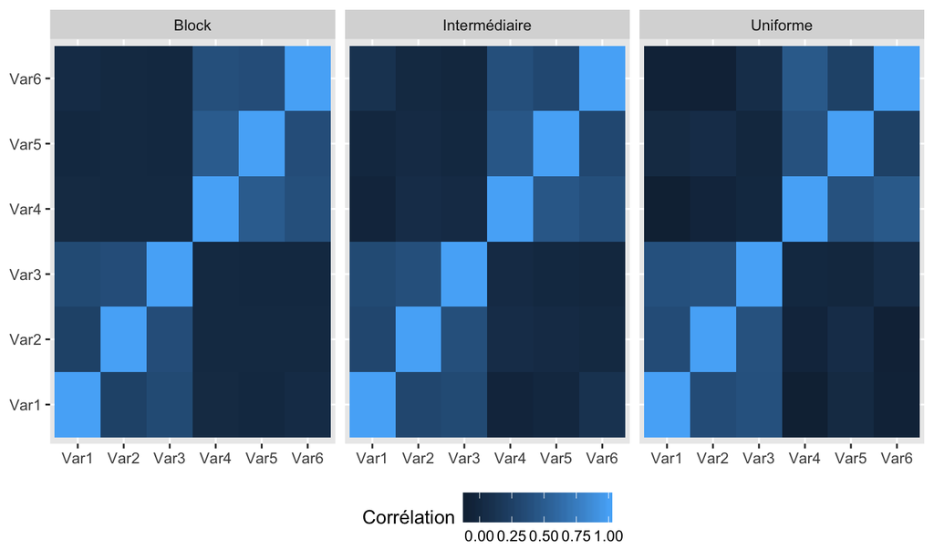

## Résultats: Structure en blocks

Une fois qu'on a simulé les données, on peut appliquer les deux méthodes (rotation et SPCA) et comparer les distances entre les vecteurs de coefficients de saturation calculés versus ceux définis au départ.

```r
print(data_distance_blocks)
```

```
##    methode       PC1       PC2       PC3       PC4       PC5        PC6
## 1:    RPCA 0.6843723 0.7231190 0.8556355 0.9403589 0.7983338 0.85372221
## 2:    SPCA 0.1614525 0.1592172 0.2344187 0.2931315 0.1826404 0.03470073
```

## Résultats: Structure uniforme

Voici les résultats pour la structure uniforme.

```r
print(data_distance_platte)
```

```
##    methode       PC1       PC2       PC3       PC4       PC5       PC6
## 1:    RPCA 0.9105189 0.8352474 0.9971168 0.8631849 0.8638496 0.8541383
## 2:    SPCA 0.5683773 0.6179552 0.6254354 0.3066725 0.6622014 0.4210572
```

## Résultats: Structure intermédiaire

Voici les résultats pour la structure intermédiaire.

```r
print(data_distance_int)
```

```
##    methode       PC1       PC2       PC3       PC4       PC5       PC6
## 1:    RPCA 0.7303505 0.9445121 0.8419008 0.8628739 0.8807077 0.8635864
## 2:    SPCA 0.5717428 0.6239981 0.7139407 0.8203731 0.7318472 0.5965195
```

## Analyse des résultats

Après avoir effectué l'étude de simulation, on peut conclure que:

- La méthode d'ACP parcimonieuse reconstruit mieux les coefficients de saturation, et ce, pour les \(3\) types de structure que les rotations.

## Jeu de données pitprops

Revenons au jeu de données `pitprops` introduit en début de la présentation et appliquons l'analyse en composante principale parcimonieuse.

- Méthode: SPCA
- Librairie: **elasticnet**
- Fonction: *spca*

## Fonction *spca*

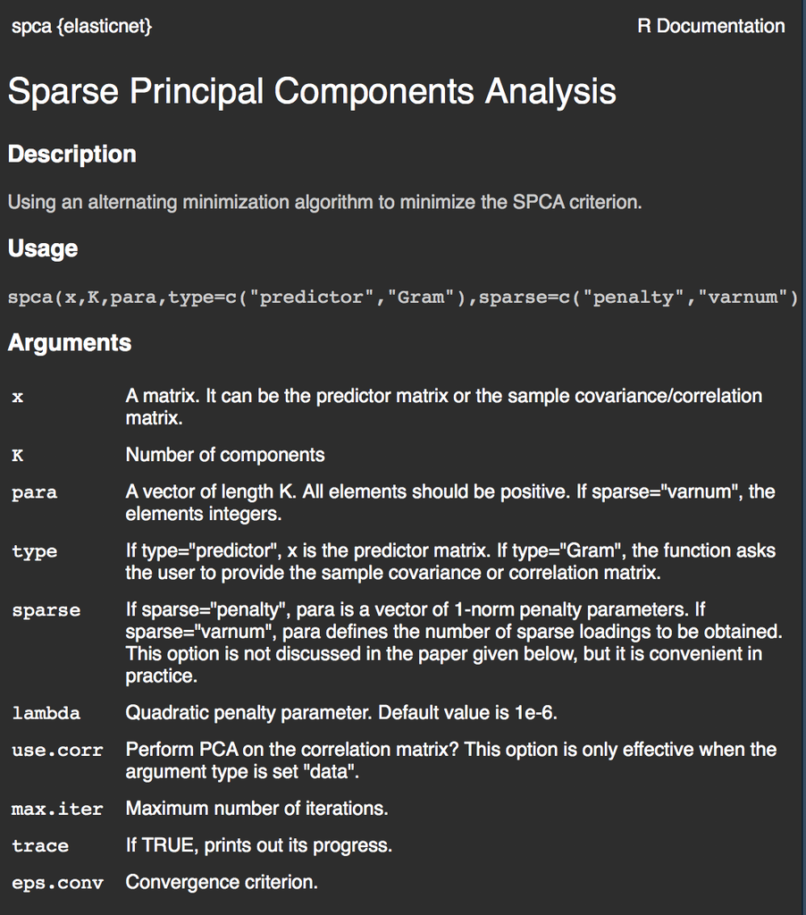

## Définir nos paramètres

Voici les paramètres choisis pour l'exemple `pitprops` et l'application de la fonction *spca*.

\[ \lambda=0.000001 \\ \lambda_1= [0.06, 0.16, 0.1, 0.5, 0.5, 0.5] \]

```r
lambda <- 0.000001
lambda_1 <- c(0.06, 0.16, 0.1, 0.5, 0.5, 0.5)

spca_pitprops <- spca(pitprops,
                      K = 6,
                      type = "Gram",
                      sparse = "penalty",
                      para = lambda_1,
                      lambda = lambda)
```

## Résultat de l'ACP parcimonieuse

```r
spca_pitprops$loadings
```

```
##                PC1         PC2         PC3 PC4 PC5 PC6
## topdiam -0.4773598  0.00000000  0.00000000   0   0   0
## length  -0.4758876  0.00000000  0.00000000   0   0   0
## moist    0.0000000  0.78471386  0.00000000   0   0   0
## testsg   0.0000000  0.61935898  0.00000000   0   0   0
## ovensg   0.1765675  0.00000000  0.64065264   0   0   0
## ringtop  0.0000000  0.00000000  0.58900859   0   0   0
## ringbut -0.2504731  0.00000000  0.49233189   0   0   0
## bowmax  -0.3440474 -0.02099748  0.00000000   0   0   0
## bowdist -0.4163614  0.00000000  0.00000000   0   0   0
## whorls  -0.4000254  0.00000000  0.00000000   0   0   0
## clear    0.0000000  0.00000000  0.00000000  -1   0   0
## knots    0.0000000  0.01333114  0.00000000   0  -1   0
## diaknot  0.0000000  0.00000000 -0.01556891   0   0   1
```

## Comparaison pour la 1er composante

Voici les vecteurs de coefficients de saturation pour la 1er composante principale (\(\alpha_1\)) pour les \(3\) différentes méthodes.

```
##             PCA        RPCA       SPCA
##  1: -0.40379375  0.91158833 -0.4773598
##  2: -0.40554469  0.93507670 -0.4758876
##  3: -0.12440384  0.13423685  0.0000000
##  4: -0.17322061  0.12499995  0.0000000
##  5: -0.05717394 -0.14943647  0.1765675
##  6: -0.28442510  0.35345951  0.0000000
##  7: -0.39984124  0.62462240 -0.2504731
##  8: -0.29355595  0.55829922 -0.3440474
##  9: -0.35662900  0.77348209 -0.4163614
## 10: -0.37891541  0.68731321 -0.4000254
## 11:  0.01109383  0.05138797  0.0000000
## 12:  0.11508371 -0.06634932  0.0000000
## 13:  0.11251370  0.07523732  0.0000000
```

## Coefficients tirés vers 0

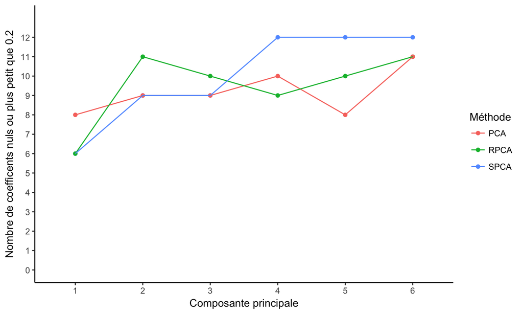

## Autres implications

Il existe une autre méthode connue que nous n'avons pas touchée dans cette présentation. Il s'agit de la méthode PMD.

- Basée sur la décomposition pénalisée de la matrice de covariance (ou corrélation).
- On peut retrouver une implémentation de cette méthode en **R** dans la librairie **PMA**.

## Références

- ESL section 14.5.5
- Jolliffe, Ian T., Nickolay T. Trendafilov, and Mudassir Uddin. ”A modified principal com- ponent technique based on the LASSO.” Journal of Computational and Graphical Statistics 12.3 (2003) : 531-547.
- Witten, Daniela M., Robert Tibshirani, and Trevor Hastie. ”A penalized matrix decomposi- tion, with applications to sparse principal components and canonical correlation analysis.” Biostatistics 10.3 (2009) : 515-534.